# Learning Activity: Association–Quantitative versus Categorical

Tian Zheng

December 7, 2015

### Association between a quantitative variable and a categorical variable.

Let’s first visualize the `InsectSprays` data.

- Using the `plot` command, we ask `R` to plot `count` against `spray` from the dataset `InsectSparys`. `xlab` and `ylab` are options we can specify to label the X and Y axes.
- `R` automatically detects that `spary` is a categorical variable and `count` is a quantitative variable. So it uses side-by-side boxplots to visualize variation in Y (`count`) given different values of the X variable (`spray`).

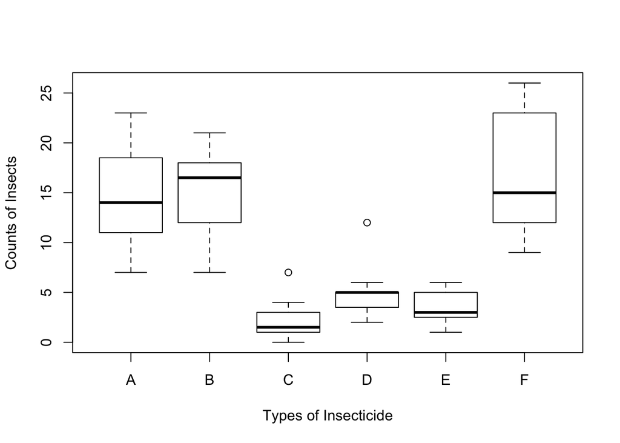

```r
plot(count~spray, data=InsectSprays,
     xlab="Types of Insecticide",
     ylab="Counts of Insects")
```

- In this module, we learnt about the method of Analysis of Variance. In the output, you will see a column under the heading `Sum Sq`, which stands for sum of squares.
- The value in the row `spary` is the group sum of squares (SSG) as the groups are defined by the values of `spray`. The value in the row `Residuals` is the error sum of squares (SSE).
- The `anova` command evaluate the Analysis of Variance test to see whether the association observed between `spray` and `count` is statistical significant. The null hypothesis is that the mean of `count` does not depend on values of `spray`.
- In this example, the p value (value under `Pr(>F)`) is quite small. Here `<2.2 e -16` means $<2.2\times 10^{-16}$. This indicates the patterns we see in the above plot is quite unlikely to occur purely by chance.

```r
anova(lm(count~spray, data=InsectSprays))
```

```
## Analysis of Variance Table
##
## Response: count
##           Df Sum Sq Mean Sq F value    Pr(>F)
## spray      5 2668.8  533.77  34.702 < 2.2e-16 ***
## Residuals 66 1015.2   15.38
## ---
## Signif. codes:  0 '***' 0.001 '**' 0.01 '*' 0.05 '.' 0.1 ' ' 1
```